# Nile River Predictions

Fred Viole

11/25/2019

## Intro

In this problem, we are going to forecast the last 10 years of the Nile river overflow data, available in the `pracma` package. Surprisingly, I could not locate a current time-series forecasting methodology applied to this dataset.

We will forecast the last 10 years, or 120 montly periods.

### Install the Latest Version of `NNS (>= 4.7)`

```r
library(devtools); install_github('OVVO-Financial/NNS', ref = "NNS-Beta-Version")
library(NNS)
library(pracma)
library(ggplot2)
library(zoo)
```

## `NNS` Methodology

### Step 1: Read Data, Create Train and Test Sets

In this code chunk we will read the variable, parse and create a time series. We will create the train set `nile_ts_train` and the test set `nile_ts_test`. We will also identify the number of periods to forecast `h` and the length of training set `nile_ts_train`.

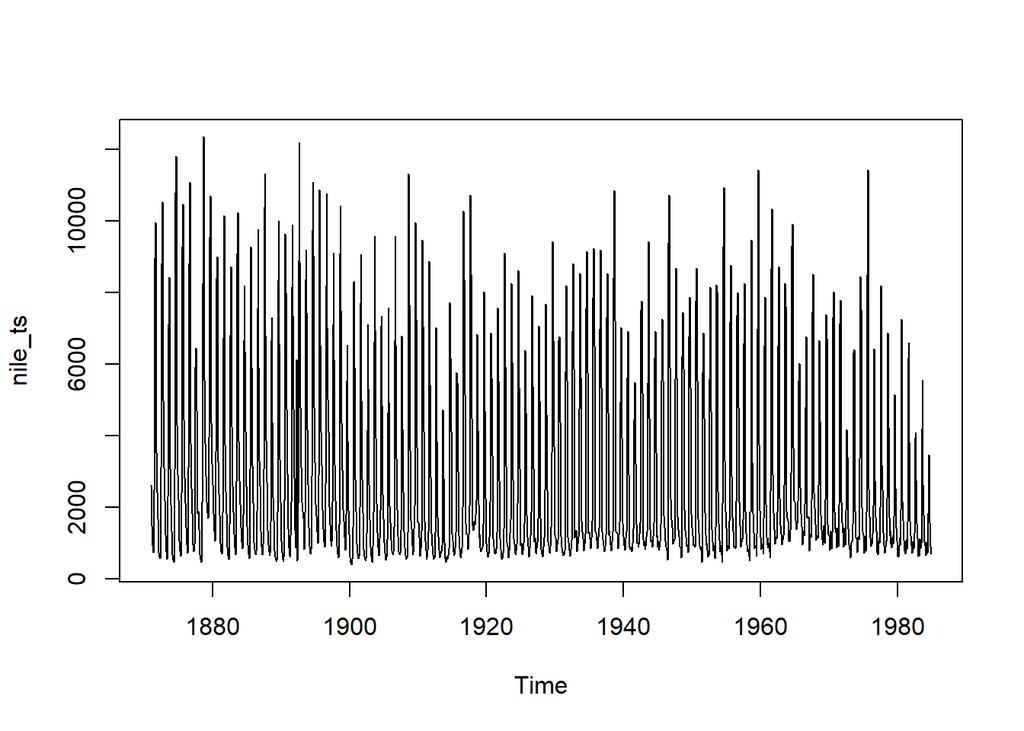

```r
data("nile")
nile_dt <- nile[, 2:13]
nile_ts <- ts( c(t(nile[, 2:13])), frequency = 12, start = c(1871, 1) )

plot(nile_ts)
```

```r
h = 120
train_length <- length(nile_ts) - h

nile_ts_train <- head(nile_ts, train_length)
nile_ts_test <- tail(nile_ts, h)
```

### Step 2: `seasonal.factor`

Next we will estimate the `seaonal.factor`s with the `NNS.seas` function and then use a mod 12 call on those periods, since we have monthly data. Thus every `seasonal.factor` will have an annual interpretation.

```r
periods <- NNS.seas(nile_ts_train, modulo = 12,
                    mod.only = FALSE, plot = FALSE)$periods

periods
```

```
##   [1] 420 539 432 516 624 503 599 395 611 587 347 551 491 108 444 276 216 419
##  [19]  84 227 324 478 623 479 497 156 311 431 490 323 466 359 120 240  60 467
##  [37] 455 264 168 132 425 575  12 372 564  36 527 540 252 371 180 552 228 563
##  [55] 443 300  48 515 450  24 407 454  72 528 335 144 461 275 588 348 600 617
##  [73] 473 622 396 574 593 383 312 360 336  96 263 610 239 485 287 509 204 521
##  [91] 533 192 598 550 251 612 477 492 504 489 557 582 437 438 569 581 191 545
## [109] 288 456 538 517 378 573 586 330 465 346 299 480 462 394 414 502 605 408
## [127] 468 421 501 318 384 366 426 334 210 453 541 534 568 382 526 562 402 576
## [145] 322 313 553 203 418 258 606 442 186 138 354 510 496 215 449 325 367 592
## [163] 179 430 433  42 618 222 546 474 558 390 565 406 361 549 609  66 301 621
## [181] 358 282 150 505 613 349 337 445 537 277 486 529 126 514 162 409 469 566
## [199] 289   6  30  54 370 373 397 590 294 296  90 248 253 198 601 356 389 493
## [217]  78 589 368 585 102  18 498 422 270 265 148 140 522 404 114 229 196 237
## [235] 594 352 570 124 614 583 142 284 530 412 376 217 306 518 602  28 494 470
## [253] 400 292   4  44 578 554 332 174 482  20  16 208 364  52   8 234 380 184
## [271] 164 506 116 200 319 316 211  85 112 115 130 104 109 166  83 170 249 103
## [289]  82  71  73 133 139  65  89  25   5   1 636
```

### Step 3: Optimize the Combination of Frequencies and Forecast

To derive the optimum parameters in the `NNS.ARMA.optim` function, we typically use `(2*h)` periods as the in-training-sample test set. This can vary if `h` becomes prohibitively large in conjuction with a large number of `periods`.

Neither `h` nor `periods` are near the levels we worked with in the [previous tides example](https://htmlpreview.github.io/?https://github.com/OVVO-Financial/NNS/blob/NNS-Beta-Version/examples/tides.html).

```r
arma_parameters <- NNS.ARMA.optim(nile_ts_train,
                                  training.set = (length(nile_ts_train)-2*h),
                                  seasonal.factor = periods)
```

```
## [1] "CURRNET METHOD: lin"
## [1] "COPY LATEST PARAMETERS DIRECTLY FOR NNS.ARMA() IF ERROR:"
## [1] "NNS.ARMA(... method =  'lin' , seasonal.factor =  c( 12 ) ...)"
## [1] "CURRENT lin OBJECTIVE FUNCTION = 241275238.424556"
## [1] "NNS.ARMA(... method =  'lin' , seasonal.factor =  c( 12, 156 ) ...)"
## [1] "CURRENT lin OBJECTIVE FUNCTION = 238812875.594632"
## [1] "NNS.ARMA(... method =  'lin' , seasonal.factor =  c( 12, 156, 36 ) ...)"
## [1] "CURRENT lin OBJECTIVE FUNCTION = 237376129.206924"
## [1] "NNS.ARMA(... method =  'lin' , seasonal.factor =  c( 12, 156, 36, 60 ) ...)"
## [1] "CURRENT lin OBJECTIVE FUNCTION = 237188741.888381"
## [1] "NNS.ARMA(... method =  'lin' , seasonal.factor =  c( 12, 156, 36, 60, 191 ) ...)"
## [1] "CURRENT lin OBJECTIVE FUNCTION = 231459939.567081"
## [1] "NNS.ARMA(... method =  'lin' , seasonal.factor =  c( 12, 156, 36, 60, 191, 84 ) ...)"
## [1] "CURRENT lin OBJECTIVE FUNCTION = 228389451.336454"
## [1] "NNS.ARMA(... method =  'lin' , seasonal.factor =  c( 12, 156, 36, 60, 191, 84, 108 ) ...)"
## [1] "CURRENT lin OBJECTIVE FUNCTION = 227625864.732671"
## [1] "BEST method = 'lin', seasonal.factor = c( 12, 156, 36, 60, 191, 84, 108)"
## [1] "BEST lin OBJECTIVE FUNCTION = 227625864.732671"
## [1] "CURRNET METHOD: nonlin"
## [1] "COPY LATEST PARAMETERS DIRECTLY FOR NNS.ARMA() IF ERROR:"
## [1] "NNS.ARMA(... method =  'nonlin' , seasonal.factor =  c( 12, 156, 36, 60, 191, 84, 108 ) ...)"
## [1] "CURRENT nonlin OBJECTIVE FUNCTION = 213836111.422288"
## [1] "BEST method = 'nonlin' PATH MEMBER = c( 12, 156, 36, 60, 191, 84, 108)"
## [1] "BEST nonlin OBJECTIVE FUNCTION = 213836111.422288"
## [1] "CURRNET METHOD: both"
## [1] "COPY LATEST PARAMETERS DIRECTLY FOR NNS.ARMA() IF ERROR:"
## [1] "NNS.ARMA(... method =  'both' , seasonal.factor =  c( 12, 156, 36, 60, 191, 84, 108 ) ...)"
## [1] "CURRENT both OBJECTIVE FUNCTION = 199846906.351454"
## [1] "BEST method = 'both' PATH MEMBER = c( 12, 156, 36, 60, 191, 84, 108)"
## [1] "BEST both OBJECTIVE FUNCTION = 199846906.351454"
```

```r
arma_parameters
```

```
## $periods
## [1]  12 156  36  60 191  84 108
##
## $weights
## NULL
##
## $obj.fn
## [1] 199846906
##
## $method
## [1] "both"
##
## $bias.shift
## [1] 0
```

The `arma_parameters$periods` can be interpreted as showing the Nile overflow to contain 1, 13, 3, 5, 15.9166667, 7, 9 years cycle components.

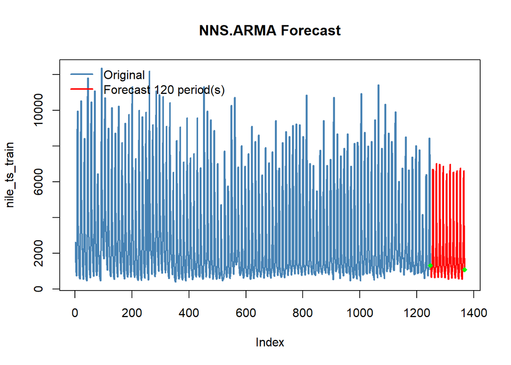

```r
nns_estimates <- NNS.ARMA(nile_ts_train,
                          h = h,
                          method = arma_parameters$method,
                          seasonal.factor = arma_parameters$periods,
                          weights = arma_parameters$weights,
                          seasonal.plot = FALSE) + arma_parameters$bias.shift
```

### Step 4: Evaluate the Results

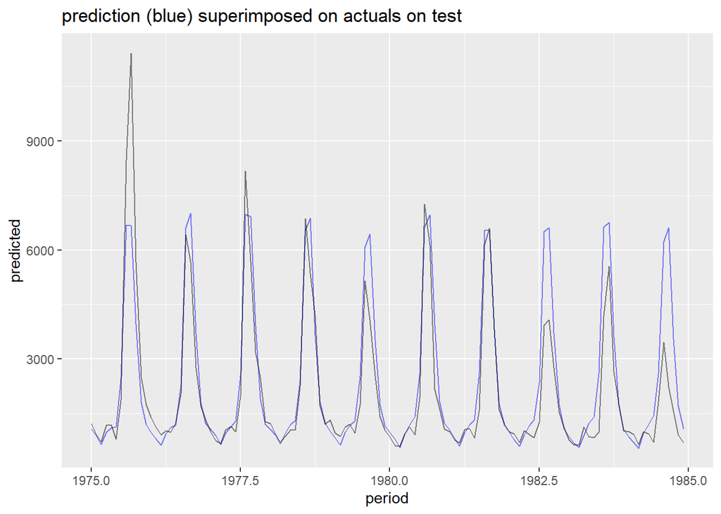

```r
dates <- as.yearmon(time(nile_ts))

ggplot_data <- data.frame(cbind(period=tail(dates, h), predicted = nns_estimates, actual = nile_ts_test))

ggplot(aes(x=period), data=ggplot_data) +
  geom_line(aes(y=predicted), color='blue', alpha=0.5) +
  geom_line(aes(y=actual), color='black', alpha=0.5) +
  ggtitle("prediction (blue) superimposed on actuals on test")
```

#### R-squared for Nonparametric Models

The R-squared[^1] between predicted and actual is the presented metric.

$$R^2 = \frac{[\sum_{i=1}^n (y_i - \bar{y})(\hat{y_i} - \bar{y})]^2}{\sum_{i=1}^n (y_i - \bar{y})^2\sum_{i=1}^n (\hat{y_i} - \bar{y})^2}$$

```r
(sum((nns_estimates - mean(nile_ts_test)) * (nile_ts_test - mean(nile_ts_test))) ^ 2) / (sum((nile_ts_test - mean(nile_ts_test)) ^ 2) * sum((nns_estimates - mean(nile_ts_test)) ^ 2))
```

```
## [1] 0.7873282
```

#### NSE

The Nash–Sutcliffe model efficiency coefficient (NSE) is used to assess the predictive power of hydrological models. It is defined as:

$$NSE = 1- \frac{\sum_{t=1}^T (\hat{y}_t - y_t)^2}{\sum_{t=1}^T (y_t - \bar{y})^2}$$

Nash–Sutcliffe efficiency can range from $-\infty$ to 1. An efficiency of 1 (NSE = 1) corresponds to a perfect match of modeled discharge to the observed data. An efficiency of 0 (NSE = 0) indicates that the model predictions are as accurate as the mean of the observed data, whereas an efficiency less than zero (NSE < 0) occurs when the observed mean is a better predictor than the model or, in other words, when the residual variance (described by the numerator in the expression above), is larger than the data variance (described by the denominator). Essentially, the closer the model efficiency is to 1, the more accurate the model is. Threshold values to indicate a model of sufficient quality have been suggested between 0.5 < NSE < 0.65. For the case of regression procedures (i.e. when the total sum of squares can be partitioned into error and regression components), the Nash–Sutcliffe efficiency is equivalent to the Coefficient of determination (R2), thus ranging between 0 and 1.

```r
NSE=function(x,y){
  NSE=1- ( sum((x-y)^2) / sum((y-mean(y))^2) )
  return(NSE)
}

NSE(nns_estimates, nile_ts_test)
```

```
## [1] 0.7602958
```

## Comments

This dataset is actually quite difficult to forecast, yet `NNS` was able to surpass the sufficient quality threshold. I look forward to analyzing alternative methods of forecasting and improving `NNS`’s ability!

If you found this presentation interesting or useful, or have another method to share, please feel free to reach out via e-mail: ovvo.financial.systems@gmail.com

Thanks for your interest!

[^1]: See Hayfield and Racine https://cran.r-project.org/web/packages/np/vignettes/np.pdf